# ESM 204 Assignment 3

Julia Wilson

2022-05-06

## Overview

The Biden Administration’s “interim” value is $51 per metric ton of CO2. The electricity sector is the second largest source of greenhouse gas emissions in the U.S. (after transportation). In this analysis, we will consider the distributional consequences of imposing a household electricity tax based on the SCC to address the climate change problem.

## Analysis

The data includes the following: - Consumers can be separated into two income groups: “high” and “low.” - Price (in $) and quantity (in kWh) estimates of demand per month for the two groups.

The analysis will show linear regressions (with an intercept) to estimate the demand curves for “high” and “low” income consumers under the following scenarios:

- Initially, there is no tax on electricity consumption.
- The current electricity price (without any taxes) is $.10 per kWh.
- The marginal cost of producing a kWh of electricity is linear and has a price-intercept of 0.

### **1. Marginal External Cost of electricity**

Assuming one kWh of electricity emits 0.85 pounds of CO2 and the interim SCC is $51/ton, we can then calculate the MEC per kWh.

The marginal external cost per kWh of electricity is $0.02.

### **2. Aggregations**

**Aggregate Demand Curve** To find the aggregate demand curve, we will first find the high and low income demand curves.

**Low Income Demand Curve:**

*P = 23.37 - 0.0001102Q*

**High Income Demand Curve:**

*P = 31.61 - 0.000052Q*

```r
# Demand model from sample code

demand <- function(p, model){
  q <- (p - model$coefficients[[1]])/model$coefficients[[2]]
  q <- ifelse(q<0,0,q)
  return(q)
}
```

```r
# Aggregate demand from code sample

demand_agg <- function(p){
  q <- demand(p, demand_low) + demand(p, demand_high)
  return(q)
}

# demand_agg(10) = 536,719.5
```

With the income-based demand curves, we can sum horizontally to find the **aggregate demand curve:** 29.78135 - 0.00004(Qagg)

```r
# Make a vector and extract the lm
price = seq(0, 30, length.out = 100)

Qagg <- map(price, demand_agg) %>%
  unlist()

agg_df<- tibble(Qagg = Qagg, price = price)

demand_agg_eq <- lm(price ~ Qagg, data = agg_df)
```

```r
# Switch the equations above so Q is on one side and then add

agg_slope <- demand_agg_eq$coefficients[2]
agg_int <- demand_agg_eq$coefficients[1]

agg_slope
```

```
##          Qagg
## -3.675993e-05
```

```r
agg_int
```

```
## (Intercept)
##    29.78135
```

```r
# Aggregate demand function is P = 29.78135 - 0.00004(Qagg)
```

**Supply Curve**

The current price is $0.10/kWh and the MC for electricity is linear with a 0 intercept.

The supply curve will pass through the agg demand curve at $0.10/kwh. We can then infer the supply curve equation will be:

*P = 0.0000192Q*

#### Visualize the data

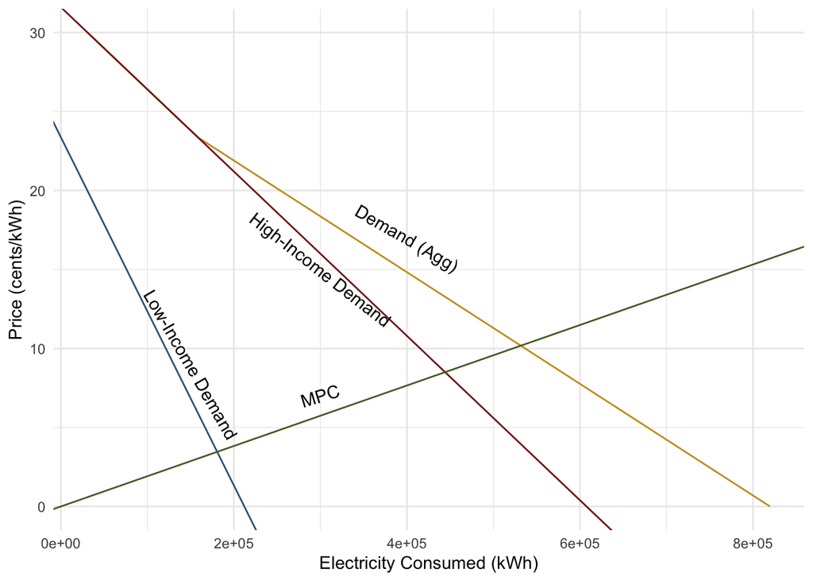

```r
ggplot(agg_df, aes(Qagg, price)) +
  geom_line(color = "goldenrod3") +
  annotate("text", x = 400000, y = 17,
           label = "Demand (Agg)", angle = -30) +
  geom_abline(color = "firebrick4",
              intercept = demand_high$coefficients[1],
              slope= demand_high$coefficients[2]) +
  annotate("text", x = 300000, y = 15,
           label = "High-Income Demand", angle = -38) +
  geom_abline(color = "steelblue4",
              intercept = demand_low$coefficients[1],
              slope= demand_low$coefficients[2]) +
  annotate("text", x = 150000, y = 9,
           label = "Low-Income Demand", angle = -60) +
  geom_abline(color = "darkolivegreen",
              intercept = 0,
              slope= supply_slope) +
  annotate("text", x = 300000, y = 7,
           label = "MPC", angle = 17) +
  labs(x = "Electricity Consumed (kWh)",
       y = "Price (cents/kWh)") +
  theme_minimal()
```

#### **Figure 1: Market for Electricity**

We can then calculate consumer and producer surplus and environmental cost. We will be cautious of converting from cents to dollars.

```r
# Consumer Surplus

# Converting cents to dollars for the y-axis
cs <- 0.5*kwh_agg*(0.305-0.10)
cs
```

```
## (Intercept)
##     53518.1
```

```r
# $53,518.12

# Producer Surplus

ps <- 0.5*kwh_agg*(.10)
# $26,106.39

# Environmental Cost
env_cost <- interim_price_kWh*kwh_agg
# $10,264.96
```

### **3. Consumer Benefit**

**Low income consumers:** consumer benefit is found by taking the area under the low income demand curve but above the current price of electricity ($0.10/kWh). This area is a triangle with base 121545 and height 13.37.

0.5 * 13.37 cents/kWh * 121545 kWh = 812,528 cents

**benefit for low income consumers is $8,125.3.**

**High income consumers:**consumer benefit is found by taking the area under the high income demand curve but above the current price of electricity ($0.10/kWh). This area is a triangle with base 415577 and height 21.61.

0.5 * 21.61 cents/kWh * 415577 kWh = 4,490,309.5 cents

**benefit for high income consumers is $44,903.1.**

total consumer surplus = 8,125.3 + 44,903.1 = $53,028.4

(8,125.3/53,028.4)*100 = 15.3% (44,903.1/53,028.4)*100 = 84.7%

**low income consumers receive 15.3% of the total benefit.**

**high income consumers receive 84.7% of the total benefit.**